# R Notebook

```r
library(vip)
```

## Introduction to tidy models

```r
Bank_churners<-read_csv("C:/Users/Lenovo/Downloads/BankChurners.csv")
glimpse(Bank_churners)
Bank_churners%>%head()
summary(Bank_churners)
skim(Bank_churners)
```

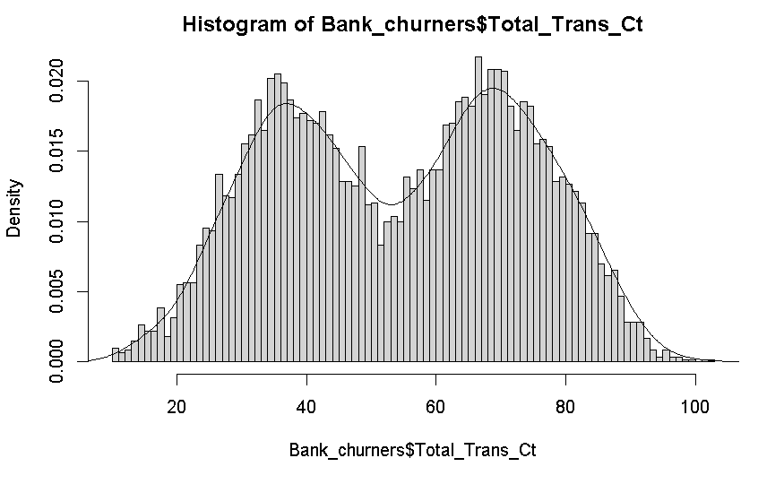

```r
hist(Bank_churners$Total_Trans_Ct,prob=TRUE,breaks=100)
lines(density(Bank_churners$Total_Trans_Ct))
```

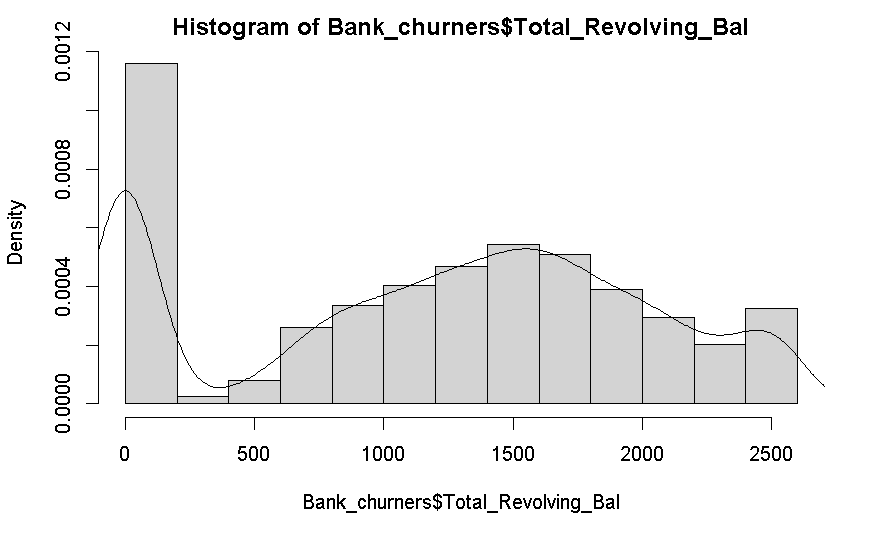

```r
hist(Bank_churners$Total_Revolving_Bal,prob=TRUE,breaks=9)
lines(density(Bank_churners$Total_Revolving_Bal))
```

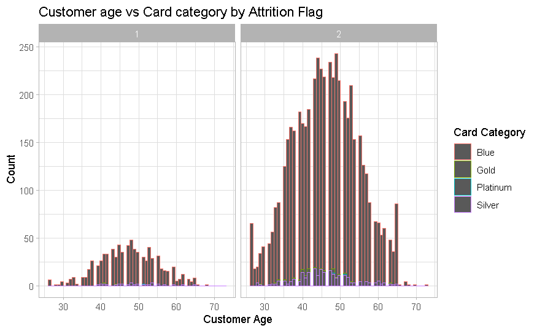

```r
ggplot(data = Bank_churners,
       mapping = aes(x = Customer_Age,
                     color = Card_Category)) +
  geom_histogram(binwidth = 0.8) +
  facet_wrap(~ Card_Category) +
  labs(title = "Customer age vs Card category by Attrition Flag",
       x = "Customer Age",
       y = "Count") +
  scale_color_discrete(name = "Card Category") +
  theme_light() +
  facet_wrap(~ Card_Category) +
  facet_grid(. ~ Attrition_Flag)
```

```r
Bank_churners$Attrition_Flag <- as.numeric(factor(Bank_churners$Attrition_Flag))

set.seed(123)

# Create a split object
Bankchurners_split <- initial_split(Bank_churners, prop = 0.90,
                                   strata = Attrition_Flag)

# Build training data set
Bankchurners_training <- Bankchurners_split %>%
                        training()

# Build testing data set
Bankchurners_test <- Bankchurners_split %>%
                    testing()
```

```r
lm_model <- linear_reg() %>%
            set_engine('lm') %>% # adds lm implementation of linear regression
            set_mode('regression')
```

```r
lm_fit <- lm_model %>%
          fit(Attrition_Flag ~ . , data=Bankchurners_training)
# View lm_fit properties
lm_fit
```

```
parsnip model object


Call:
stats::lm(formula = Attrition_Flag ~ ., data = data)

Coefficients:
                  (Intercept)                      CLIENTNUM                   Customer_Age                        GenderM
                    9.460e-01                      1.505e-10                     -9.887e-04                      7.362e-02
              Dependent_count       Education_LevelDoctorate        Education_LevelGraduate     Education_LevelHigh School
                   -1.398e-02                     -5.171e-02                     -1.669e-03                     -1.054e-03
 Education_LevelPost-Graduate      Education_LevelUneducated         Education_LevelUnknown          Marital_StatusMarried
                   -1.643e-02                     -8.740e-03                     -1.321e-02                      4.597e-02
         Marital_StatusSingle          Marital_StatusUnknown     Income_Category$40K - $60K     Income_Category$60K - $80K
                   -4.163e-03                      4.899e-03                      5.080e-02                      2.464e-02
  Income_Category$80K - $120K  Income_CategoryLess than $40K         Income_CategoryUnknown              Card_CategoryGold
                    2.298e-02                      5.213e-02                      3.922e-02                     -2.427e-02
        Card_CategoryPlatinum            Card_CategorySilver                 Months_on_book     `Total_Relationship Count`
                   -1.090e-01                     -1.465e-02                      3.411e-04                      6.234e-02
       Months_Inactive_12_mon          Contacts_Count_12_mon                   Credit_Limit            Total_Revolving_Bal
                   -3.244e-02                     -3.070e-02                      1.681e-06                      8.390e-05
              Avg_Open_To_Buy           Total_Amt_Chng_Q4_Q1                Total_Trans_Amt                 Total_Trans_Ct
                           NA                      4.902e-02                     -1.742e-05                      7.073e-03
          Total_Ct_Chng_Q4_Q1          Avg_Utilization_Ratio
                    2.561e-01                      1.110e-02
```

```r
names(lm_fit)
```

```
[1] "lvl"     "spec"    "fit"     "preproc" "elapsed"
```

To print a summary of our model, we can extract `fit` from `lm_fit` and pass it to the `summary()` function. We can explore the estimated coefficients, F-statistics, p-values, residual standard error (also known as RMSE) and R2 value.

```r
summary(lm_fit$fit)
```

```
Call:
stats::lm(formula = Attrition_Flag ~ ., data = data)

Residuals:
     Min       1Q   Median       3Q      Max
-1.01659 -0.09171  0.05278  0.17296  0.71362

Coefficients: (1 not defined because of singularities)
                                Estimate Std. Error t value Pr(>|t|)
(Intercept)                    9.460e-01  8.752e-02  10.808  < 2e-16 ***
CLIENTNUM                      1.505e-10  1.012e-10   1.487  0.13715
Customer_Age                  -9.887e-04  7.530e-04  -1.313  0.18923
GenderM                        7.362e-02  1.344e-02   5.479 4.48e-08 ***
Dependent_count               -1.398e-02  2.918e-03  -4.793 1.69e-06 ***
Education_LevelDoctorate      -5.171e-02  2.098e-02  -2.464  0.01377 *
Education_LevelGraduate       -1.669e-03  1.357e-02  -0.123  0.90209
Education_LevelHigh School    -1.054e-03  1.445e-02  -0.073  0.94183
Education_LevelPost-Graduate  -1.643e-02  2.051e-02  -0.801  0.42333
Education_LevelUneducated     -8.740e-03  1.521e-02  -0.575  0.56557
Education_LevelUnknown        -1.321e-02  1.521e-02  -0.869  0.38515
Marital_StatusMarried          4.597e-02  1.471e-02   3.124  0.00179 **
Marital_StatusSingle          -4.163e-03  1.482e-02  -0.281  0.77880
Marital_StatusUnknown          4.899e-03  1.981e-02   0.247  0.80467
Income_Category$40K - $60K     5.080e-02  1.891e-02   2.686  0.00725 **
Income_Category$60K - $80K     2.464e-02  1.703e-02   1.446  0.14814
Income_Category$80K - $120K    2.298e-02  1.619e-02   1.419  0.15599
Income_CategoryLess than $40K  5.213e-02  2.082e-02   2.503  0.01234 *
Income_CategoryUnknown         3.922e-02  2.208e-02   1.776  0.07581 .
Card_CategoryGold             -2.427e-02  5.213e-02  -0.466  0.64149
Card_CategoryPlatinum         -1.090e-01  1.926e-01  -0.566  0.57142
Card_CategorySilver           -1.465e-02  2.046e-02  -0.716  0.47383
Months_on_book                 3.411e-04  7.605e-04   0.449  0.65375
`Total_Relationship Count`     6.234e-02  2.968e-03  21.002  < 2e-16 ***
Months_Inactive_12_mon        -3.244e-02  3.734e-03  -8.686  < 2e-16 ***
Contacts_Count_12_mon         -3.070e-02  3.250e-03  -9.446  < 2e-16 ***
Credit_Limit                   1.681e-06  6.890e-07   2.440  0.01474 *
Total_Revolving_Bal            8.390e-05  6.811e-06  12.318  < 2e-16 ***
Avg_Open_To_Buy                       NA         NA      NA       NA
Total_Amt_Chng_Q4_Q1           4.902e-02  1.624e-02   3.018  0.00256 **
Total_Trans_Amt               -1.742e-05  6.595e-06  -2.642  0.00826 **
Total_Trans_Ct                 7.073e-03  4.221e-04  16.756  < 2e-16 ***
Total_Ct_Chng_Q4_Q1            2.561e-01  1.512e-02  16.935  < 2e-16 ***
Avg_Utilization_Ratio          1.110e-02  2.319e-02   0.479  0.63220
---
Signif. codes:  0 ‘***’ 0.001 ‘**’ 0.01 ‘*’ 0.05 ‘.’ 0.1 ‘ ’ 1

Residual standard error: 0.2709 on 5364 degrees of freedom
Multiple R-squared:  0.3594,    Adjusted R-squared:  0.3556
F-statistic: 94.06 on 32 and 5364 DF,  p-value: < 2.2e-16
```

We can use the `plot()` function to obtain diagnostic plots for our trained regression model. Again, we must first extract the `fit` object from `lm_fit` and then pass it into `plot()`. These plots provide a check for the main assumptions of the linear regression model.

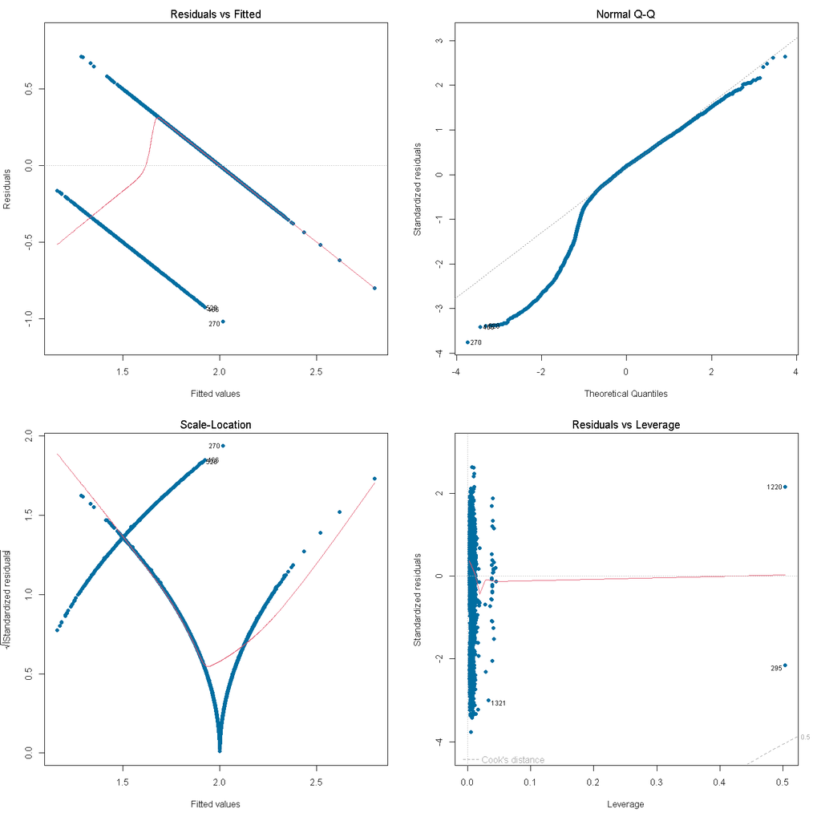

```r
par(mfrow=c(2,2)) # plot all 4 plots in one

plot(lm_fit$fit,
     pch = 16,    # optional parameters to make points blue
     col = '#006EA1')
```

### Tidy Training Results

To obtain the detailed results from our trained linear regression model in a data frame, we can use the `tidy()` and `glance()` functions directly on our trained `parsnip` model, `lm_fit`.

The `glance()` function will return performance metrics obtained on the training data such as the R2 value (`r.squared`) and the RMSE (`sigma`).

```r
# Data frame of estimated coefficients
tidy(lm_fit)
```

| term | estimate | std.error | statistic | p.value |
| --- | --- | --- | --- | --- |
| (Intercept) | 9.459659e-01 | 8.752436e-02 | 10.80802955 | 5.966706e-27 |
| CLIENTNUM | 1.504822e-10 | 1.012191e-10 | 1.48669803 | 1.371534e-01 |
| Customer_Age | -9.886790e-04 | 7.529707e-04 | -1.31303771 | 1.892264e-01 |
| GenderM | 7.361955e-02 | 1.343783e-02 | 5.47853115 | 4.484244e-08 |
| Dependent_count | -1.398243e-02 | 2.917523e-03 | -4.79256889 | 1.691013e-06 |
| Education_LevelDoctorate | -5.170574e-02 | 2.098340e-02 | -2.46412520 | 1.376595e-02 |
| Education_LevelGraduate | -1.669494e-03 | 1.357014e-02 | -0.12302704 | 9.020903e-01 |
| Education_LevelHigh School | -1.054259e-03 | 1.444719e-02 | -0.07297328 | 9.418301e-01 |
| Education_LevelPost-Graduate | -1.642664e-02 | 2.051481e-02 | -0.80072097 | 4.233287e-01 |
| Education_LevelUneducated | -8.739572e-03 | 1.520931e-02 | -0.57461986 | 5.655725e-01 |

[output cut: 24 more lines]

```r
# Performance metrics on training data
glance(lm_fit)
```

| r.squared | adj.r.squared | sigma | statistic | p.value | df | logLik | AIC | BIC | deviance | df.residual | nobs |
| --- | --- | --- | --- | --- | --- | --- | --- | --- | --- | --- | --- |
| 0.3594454 | 0.3556241 | 0.2708654 | 94.0623 | 0 | 32 | -592.2603 | 1252.521 | 1476.703 | 393.5464 | 5364 | 5397 |

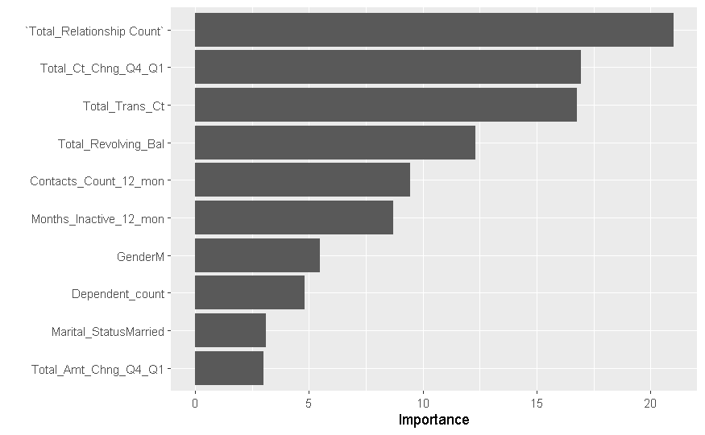

```r
vip(lm_fit)
```

```r
predict(lm_fit, new_data = Bank_churners)
```

| .pred |
| --- |
| 2.164832 |
| 2.617579 |
| 2.170179 |
| 2.073145 |
| 2.331788 |
| 1.805726 |
| 2.035363 |
| 1.817894 |
| 2.182300 |
| 1.930230 |

[output cut: 990 more lines]

```r
Bank_churners_results <- predict(lm_fit, new_data = Bank_churners) %>%
                            bind_cols(Bankchurners_test)
```

[output not shown]